# Gut microbiota and life-history traits

J. Ignacio Lucas Lledó

27/4/2020

# Amplicons or genera

When estimating and interpreting diversity, we can use amplicon sequence variants (ASV) or genera. When using ASVs it is important to take sequence similarity into account, because otherwise we could overestimate the functional diversity of groups with mostly neutral diversity.

Matrices `Ar` and `Ar.prop` contain ASV counts and frequencies (respectively) in the 177 samples. I need to create equivalent matrices for genera, before filtering. There are 82 amplicons without attributed genus. I will add the *Unknown* genus, to be able to include those amplicons in the analysis.

```r
stopifnot(all.equal(rownames(Traits), colnames(Ar)))
Traits[is.na(Traits$Genus), 'Genus'] <- 'unknown'
# Having no NA values in Genus, I can use "==" below, instead of "%in%".
# Using sapply(..., simplify=FALSE) instead of lapply() I get columns named by genus
Genera.counts <- do.call(cbind,
                         sapply(unique(Traits$Genus),
                                function(x, G=Traits, M=Ar) {
                                  f <- rownames(G[G$Genus == x,])
                                  rowSums(M[, f, drop=FALSE])
                                },
                                simplify = FALSE))
# I generate genus frequencies by adding up ASV frequencies, instead of normalizing
# the counts because the ASV relative frequencies may not add up to 1 if some ASVs
# have already been filtered out.
Genera.prop <- do.call(cbind,
                       sapply(unique(Traits$Genus),
                              function(x, G=Traits, M=Ar.prop) {
                                f <- rownames(G[G$Genus == x,])
                                rowSums(M[, f, drop = FALSE])
                              },
                              simplify = FALSE))
```

Here I am running most analyses keeping replicates separate, in contrast to the analysis in `2020-04-22`, for example, where I joined the counts from the 3 or 4 replicates of each isoline-age combination. This different approach calls for a different filtering strategy. It is not appropriate to filter ASVs by their isoline-level minimum prevalence or abundance, because at the replicate level the power to detect ASVs may be 3 to 4 times lower. Thus, I must be more demanding on the minimum proportion (too low frequency ASVs may not be observable in individual samples) and on minimum prevalence (there are only 24 isolines, but 177 samples). I also need to remove samples with too few counts (E31D and L35C), before using them in the calculation of average proportions and prevalences.

Filtering low frequency ASVs make samples with different sequencing effort more comparable. A different question is if the same filter must be applied for early and late samples. Up to now I have been using the same set of ASVs to measure diversity early and late, by requiring the thresholds to be met among either early or late samples. I realize this can have the effect of having very different abundance distributions in early and late samples, especially if one category was composed by a subset of the taxa in the other. Thus, this kind of filtering could upwardly bias the difference in diversity between classes of samples.

For some applications below, I need all samples in the same matrix, and therefore they must be scored for the abundance (or presence) of the same set of ASVs (or genera). An alternative filtering strategy would be to apply the filters globally: include ASVs (or genera) that meet the thresholds over all samples, not only within their age class. I didn’t use this approach before because I expect it to have the effect of homogenizing the composition between age classes: age class-specific ASVs would be less likely to meet the thresholds than ASVs present in all ages. But I suppose it is better to be conservative when testing for a difference in alpha diversity between early and late microbiomes.

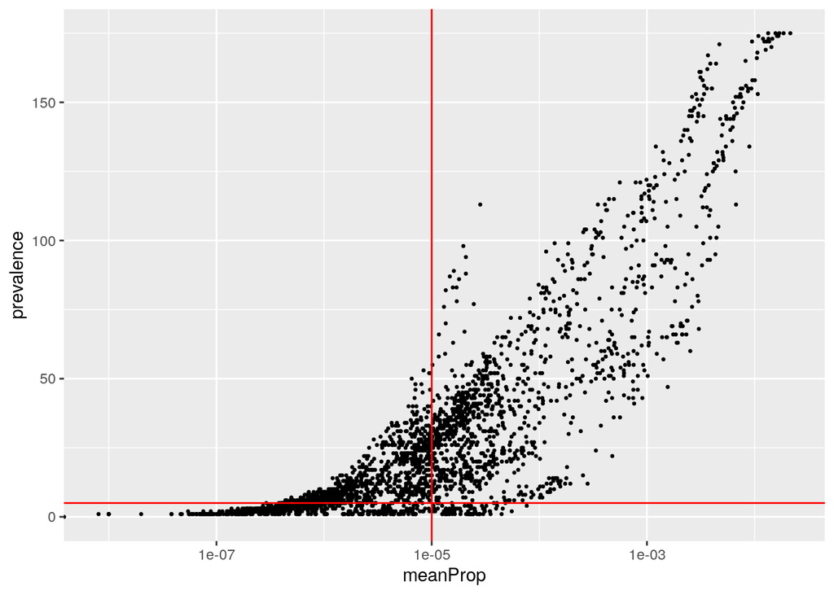

```r
Sample.filter <- rowSums(Ar) >= 3000
Traits$meanProp <- apply(Ar.prop[Sample.filter,], 2, mean)
Traits$prevalence <- colSums(Ar[Sample.filter,] > 0)
MinProp <- 1.0e-5
MinPrev <- 5

ggplot(Traits, aes(x=meanProp, y=prevalence)) +
  geom_point(size=0.5) + scale_x_log10() +
  geom_vline(xintercept=MinProp, color='red') + geom_hline(yintercept=MinPrev, color='red')
```

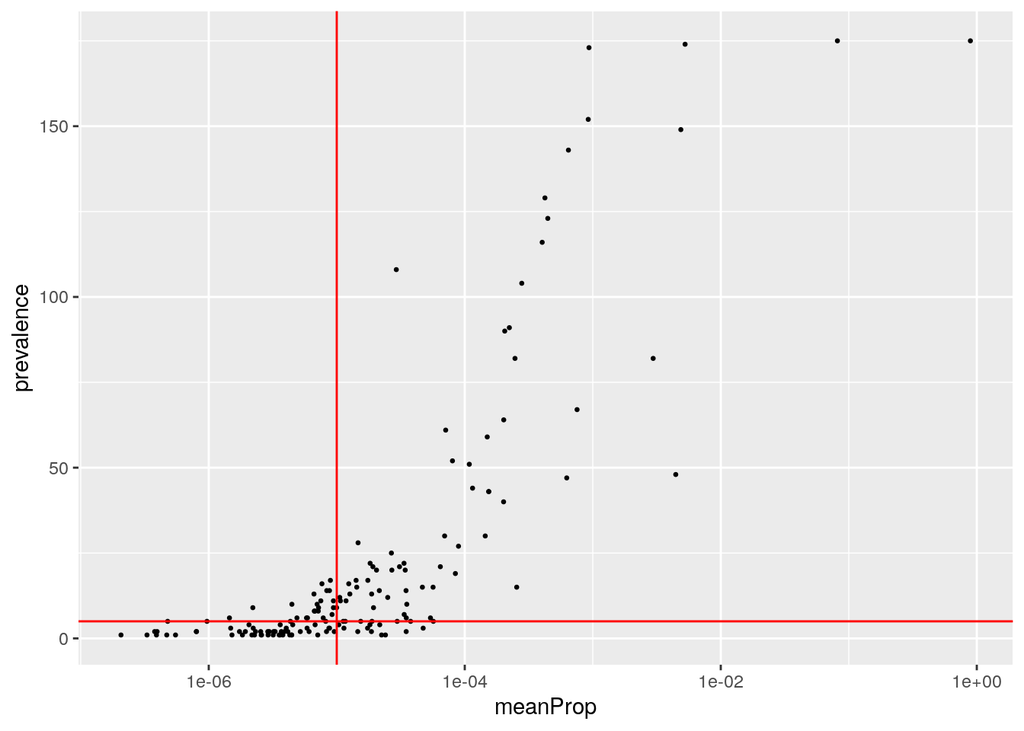

```r
ASV.filter <- Traits$meanProp >= MinProp & Traits$prevalence >= MinPrev

Genera.traits <- data.frame(
  meanProp = apply(Genera.prop[Sample.filter,], 2, mean),
  prevalence = colSums(Genera.prop[Sample.filter,] > 0)
)

ggplot(Genera.traits, aes(x=meanProp, y=prevalence)) +
  geom_point(size=0.5) + scale_x_log10() +
  geom_vline(xintercept=MinProp, color='red') + geom_hline(yintercept=MinPrev, color='red')
```

```r
Genus.filter <- Genera.traits$meanProp >= MinProp & Genera.traits$prevalence >= MinPrev
```

# Alpha diversity

The change of $\alpha$ diversity with age is quite well resolved. I learned that amplicon diversity is not reduced with age. The reason is the high resolution afforded by ASVs: even if one species (or genus) becomes dominant, it can include a large number of ASVs (just as expected under the neutral theory), to the point that ASV diversity remains high. Lesson 1: when using ASVs, a more useful measure of diversity should incorporate the phylogenetic distances among ASVs. To use the phylogenetic diversity index is the best option. An alternative is to compute genus diversity, instead of ASV diversity. To illustrate it, I include here a boxplot of phylogenetic diversities *per sample* (where samples are not aggregated by isoline and age). This is quite redundant with `2020-04-22`.

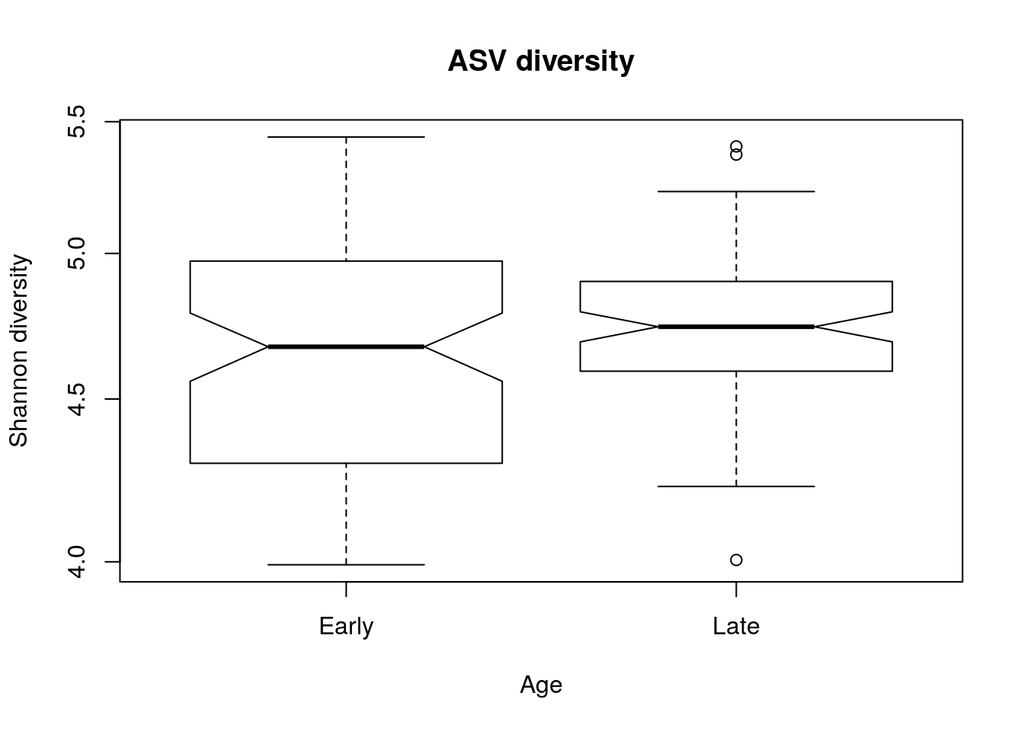

```r
ASV.alpha <- diversity(Ar[Sample.filter, ASV.filter], index = 'shannon')
boxplot(ASV.alpha ~ SampleData[Sample.filter, 'age'], xlab='Age', ylab='Shannon diversity',
        main = 'ASV diversity', log='y', notch=TRUE)
```

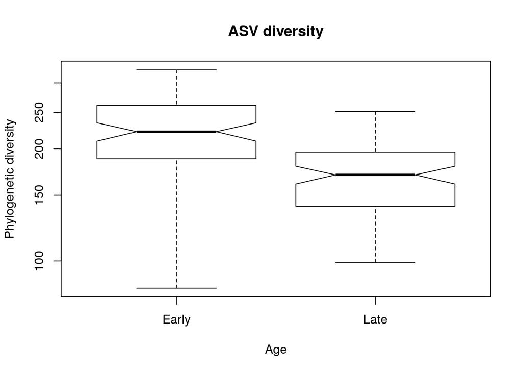

```r
ASV.pd <- pd(Ar[Sample.filter, ASV.filter], fitGTR$tree, include.root=FALSE)[,1]
boxplot(ASV.pd ~ SampleData[Sample.filter, 'age'], xlab='Age', ylab='Phylogenetic diversity',
        main = 'ASV diversity', log='y',  notch=TRUE)
```

Let’s compare it to the genus diversity.

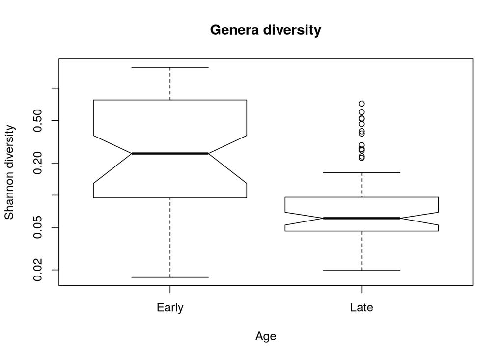

```r
Genera.alpha <- diversity(Genera.counts[Sample.filter, Genus.filter], index = 'shannon')
boxplot(Genera.alpha ~ SampleData[Sample.filter, 'age'], xlab = 'Age', ylab = 'Shannon diversity',
        main = 'Genera diversity', log='y', notch=TRUE)
```

```r
png(file='diversity.png', width = 480 * 3)
par(mfrow=c(1,3), cex=1.5)
boxplot(ASV.alpha ~ SampleData[Sample.filter, 'age'], xlab='Age', ylab='Shannon diversity',
        main = 'ASV diversity', log='y', notch=TRUE)
boxplot(ASV.pd ~ SampleData[Sample.filter, 'age'], xlab='Age', ylab='Phylogenetic diversity',
        main = 'ASV diversity', log='y',  notch=TRUE)
boxplot(Genera.alpha ~ SampleData[Sample.filter, 'age'], xlab = 'Age', ylab = 'Shannon diversity',
        main = 'Genera diversity', log='y', notch=TRUE)
dev.off()
```

Not only diversity is lower in late samples, but dispersion also seems lower.

# Beta diversity

## Test for homogeneity between early and late ages

How does microbiome change along life? One possibility is that early in life all isolines have a very similar and more generic microbiome, mostly determined by food, which is common to all isolines. Then, over time, isolines could diverge in the selective environments they offer to their microbiomes, increasing diversity among isolines. Thus, even if alpha diversity goes down, beta diversity would increase. Alternatively, the colonization events may be quite variable among isolines (or even among individual flies), in comparison to the final state late in life, as if there was a convergent ecological succession in any fly. In that case, not only alpha but also beta diversity would decrease.

In principle, I expect a decrease in $\beta$ diversity, because the general dominance of *Acetobacter* amplicons in all late samples suggest a homogeneization of microbiota with age. This can be tested with a *distance-based test for homogeneity of multivariate dispersions* (Anderson, n.d.). Below I use both `anova()` and `permutest()` from the `vegan` package (Oksanen et al. 2019).

```r
BrayDist <- vegdist(Ar[Sample.filter, ASV.filter], method='bray')
stopifnot(all.equal(labels(BrayDist), rownames(SampleData[Sample.filter,])))
anova(betadisper(BrayDist, SampleData[Sample.filter, 'age']))
```

```
## Analysis of Variance Table
##
## Response: Distances
##            Df Sum Sq Mean Sq F value    Pr(>F)
## Groups      1 1.0378 1.03779  52.804 1.211e-11 ***
## Residuals 173 3.4001 0.01965
## ---
## Signif. codes:  0 '***' 0.001 '**' 0.01 '*' 0.05 '.' 0.1 ' ' 1
```

```r
permutest(betadisper(BrayDist, SampleData[Sample.filter, 'age']))
```

```
##
## Permutation test for homogeneity of multivariate dispersions
## Permutation: free
## Number of permutations: 999
##
## Response: Distances
##            Df Sum Sq Mean Sq      F N.Perm Pr(>F)
## Groups      1 1.0378 1.03779 52.804    999  0.001 ***
## Residuals 173 3.4001 0.01965
## ---
## Signif. codes:  0 '***' 0.001 '**' 0.01 '*' 0.05 '.' 0.1 ' ' 1
```

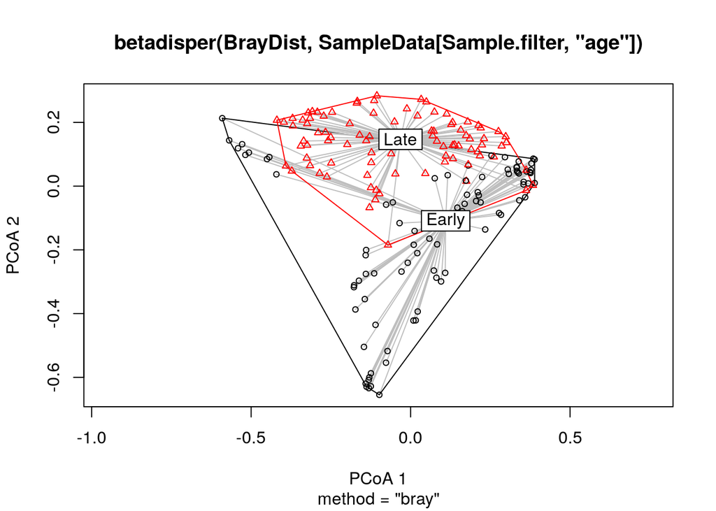

```r
plot(betadisper(BrayDist, SampleData[Sample.filter, 'age']))
```

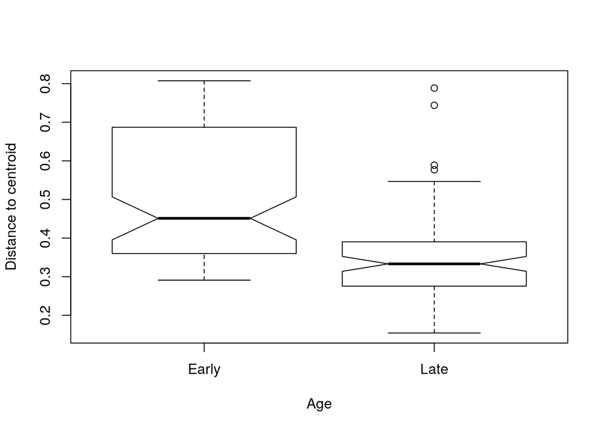

```r
boxplot(betadisper(BrayDist, SampleData[Sample.filter, 'age']), notch=TRUE, xlab='Age')
```

These results confirm that $beta$ diversity is higher early than late in life. That is, the ASV turnover is higher early than late in life, among samples. However, when dealing with $\alpha$ diversity, I dismissed diversity measures of ASV data when not using phylogenetic information. Let’s see what happens when using phylogenetic information. I use the generalized UniFrac distances (Chen et al. 2012), which allow for different ways to weight abundance. It requires the tree to be rooted. To root the tree I use as outgroup the small, monophyletic group of Bacteroidetes.

```r
Bacteroidetes <- fitGTR$tree$tip.label[fitGTR$tree$tip.label %in%
                                         rownames(Traits[Traits$Phylum=='Bacteroidetes',])]
RootedTree <- root(fitGTR$tree,
                   outgroup = Bacteroidetes,
                   resolve.root = TRUE)

unifracs <- GUniFrac(Ar[Sample.filter, ASV.filter], RootedTree, alpha=c(0, 0.5, 1))$unifracs
UFw <- as.dist(unifracs[, , 'd_1'])   # weighted UniFrac
UFu <- as.dist(unifracs[, , 'd_UW'])  # unweighted UniFrac
UFv <- as.dist(unifracs[, , 'd_VAW']) # variance-adjusted UniFrac
UF0 <- as.dist(unifracs[, , 'd_0'])   # GUniFrac with alpha 0
UF5 <- as.dist(unifracs[, , 'd_0.5']) # GUniFrac with alpha 0.5

stopifnot(all.equal(labels(UFw), rownames(SampleData[Sample.filter,])))
anova(betadisper(UFw, SampleData[Sample.filter, 'age'], add=TRUE))
```

```
## Analysis of Variance Table
##
## Response: Distances
##            Df   Sum Sq  Mean Sq F value    Pr(>F)
## Groups      1 0.041395 0.041395  30.397 1.262e-07 ***
## Residuals 173 0.235592 0.001362
## ---
## Signif. codes:  0 '***' 0.001 '**' 0.01 '*' 0.05 '.' 0.1 ' ' 1
```

```r
permutest(betadisper(UFw, SampleData[Sample.filter, 'age'], add=TRUE))
```

```
##
## Permutation test for homogeneity of multivariate dispersions
## Permutation: free
## Number of permutations: 999
##
## Response: Distances
##            Df   Sum Sq  Mean Sq      F N.Perm Pr(>F)
## Groups      1 0.041395 0.041395 30.397    999  0.001 ***
## Residuals 173 0.235592 0.001362
## ---
## Signif. codes:  0 '***' 0.001 '**' 0.01 '*' 0.05 '.' 0.1 ' ' 1
```

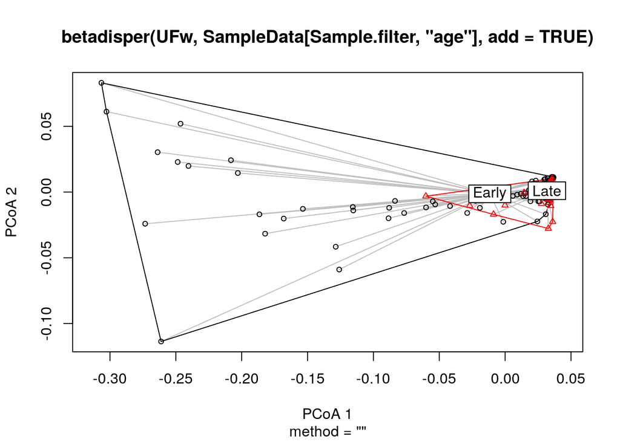

```r
plot(betadisper(UFw, SampleData[Sample.filter, 'age'], add=TRUE))
```

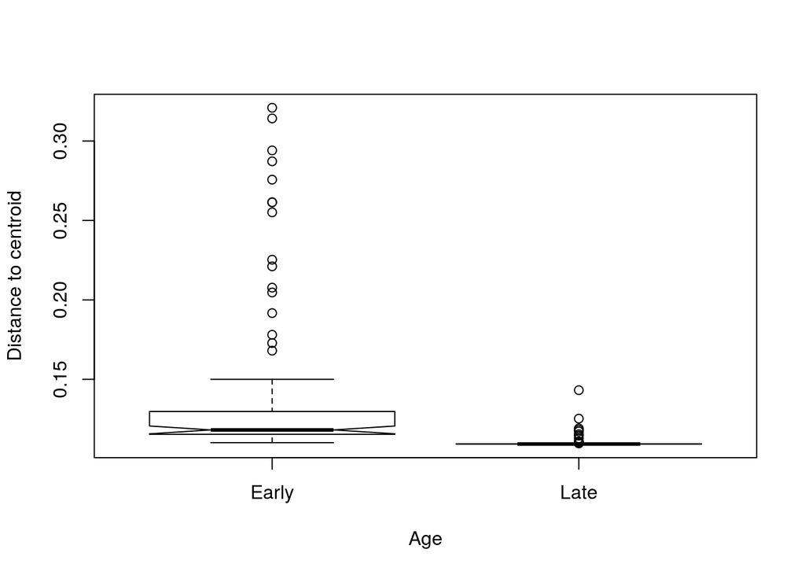

```r
boxplot(betadisper(UFw, SampleData[Sample.filter, 'age'], add=TRUE),
        notch=TRUE, xlab='Age')
```

```r
png(filename='beta.png', width=480*3)
par(mfrow=c(1,3), cex=1.2)
   plot(betadisper(UFu, SampleData[Sample.filter, 'age'], add=TRUE),
        sub='', main = 'Unweighted UniFrac')
   plot(betadisper(UF0, SampleData[Sample.filter, 'age'], add=TRUE),
        sub='', main = 'Generalised UniFrac, alpha = 0')
   plot(betadisper(UF5, SampleData[Sample.filter, 'age'], add=TRUE),
        sub='', main = 'Generalised UniFrac, alpha = 0.5')
par(mfrow=c(1,1))
dev.off()
```

## Test of homogeneity among isolines

The same method can be used to see if isolines (or isoline $\times$ age combinations) have homogeneous dispersons in the ASV space. I will compare isolines twice: first using early samples, and then late ones.

```r
isEarly <- SampleData$age == 'Early'
isLate  <- SampleData$age == 'Late'
EarlyDist <- as.dist(GUniFrac(Ar[isEarly & Sample.filter, ASV.filter],
                              RootedTree, alpha=0)$unifracs[,,'d_0'])
LateDist  <- as.dist(GUniFrac(Ar[isLate & Sample.filter,  ASV.filter],
                              RootedTree, alpha=0)$unifracs[,,'d_0'])

anova(betadisper(EarlyDist, SampleData[isEarly & Sample.filter, 'isoline']))
```

```
## Analysis of Variance Table
##
## Response: Distances
##           Df  Sum Sq   Mean Sq F value Pr(>F)
## Groups    23 0.07465 0.0032456  0.4309 0.9862
## Residuals 62 0.46696 0.0075317
```

```r
permutest(betadisper(EarlyDist, SampleData[isEarly & Sample.filter, 'isoline']))
```

```
##
## Permutation test for homogeneity of multivariate dispersions
## Permutation: free
## Number of permutations: 999
##
## Response: Distances
##           Df  Sum Sq   Mean Sq      F N.Perm Pr(>F)
## Groups    23 0.07465 0.0032456 0.4309    999  0.987
## Residuals 62 0.46696 0.0075317
```

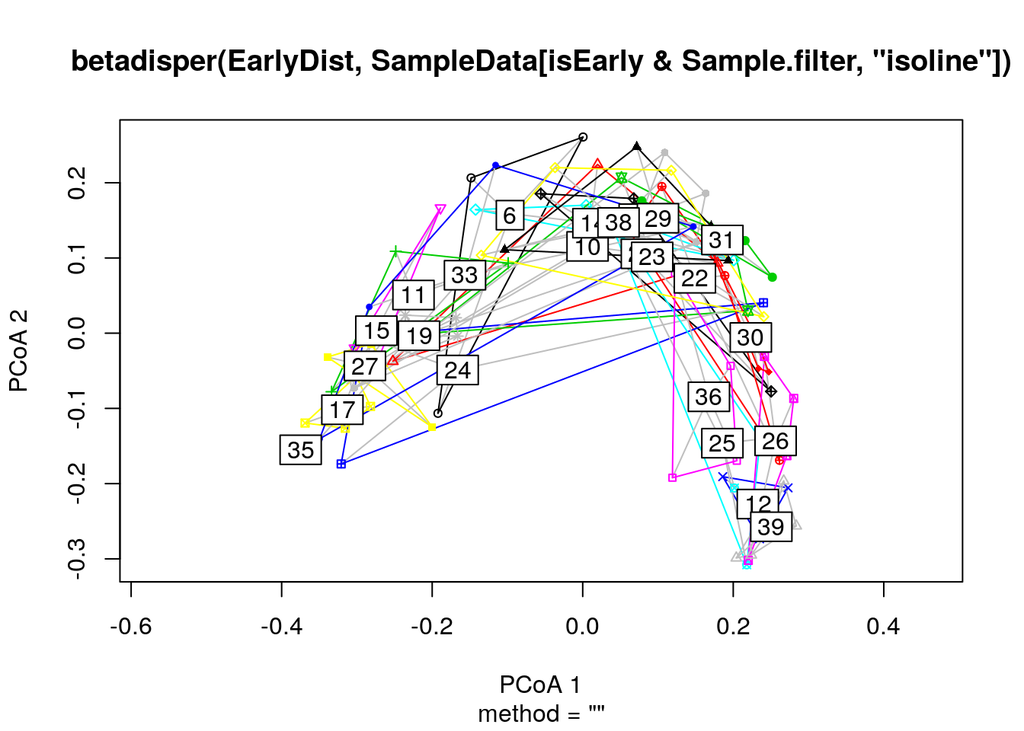

```r
plot(betadisper(EarlyDist, SampleData[isEarly & Sample.filter, 'isoline']))
```

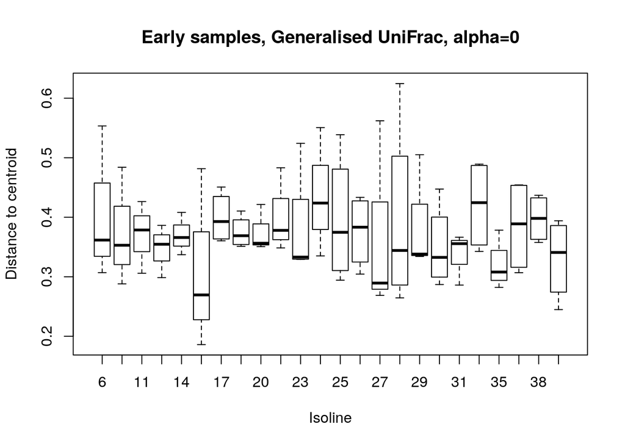

```r
boxplot(betadisper(EarlyDist, SampleData[isEarly & Sample.filter, 'isoline']),
        xlab='Isoline', main='Early samples, Generalised UniFrac, alpha=0')
```

```r
anova(betadisper(LateDist, SampleData[isLate & Sample.filter, 'isoline']))
```

```
## Analysis of Variance Table
##
## Response: Distances
##           Df  Sum Sq   Mean Sq F value Pr(>F)
## Groups    23 0.14263 0.0062015  1.4926 0.1058
## Residuals 65 0.27006 0.0041548
```

```r
permutest(betadisper(LateDist, SampleData[isLate & Sample.filter, 'isoline']))
```

```
##
## Permutation test for homogeneity of multivariate dispersions
## Permutation: free
## Number of permutations: 999
##
## Response: Distances
##           Df  Sum Sq   Mean Sq      F N.Perm Pr(>F)
## Groups    23 0.14263 0.0062015 1.4926    999  0.106
## Residuals 65 0.27006 0.0041548
```

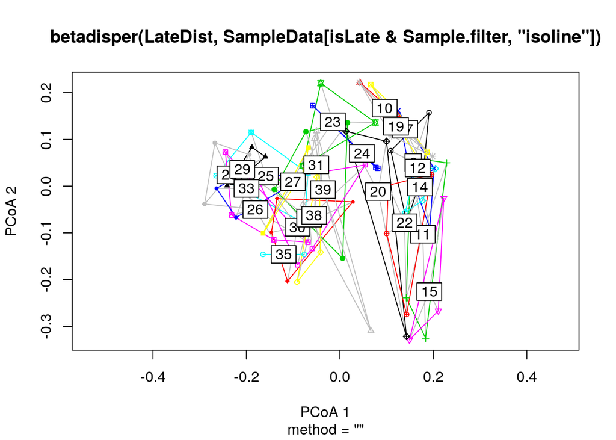

```r
plot(betadisper(LateDist, SampleData[isLate & Sample.filter, 'isoline']))
```

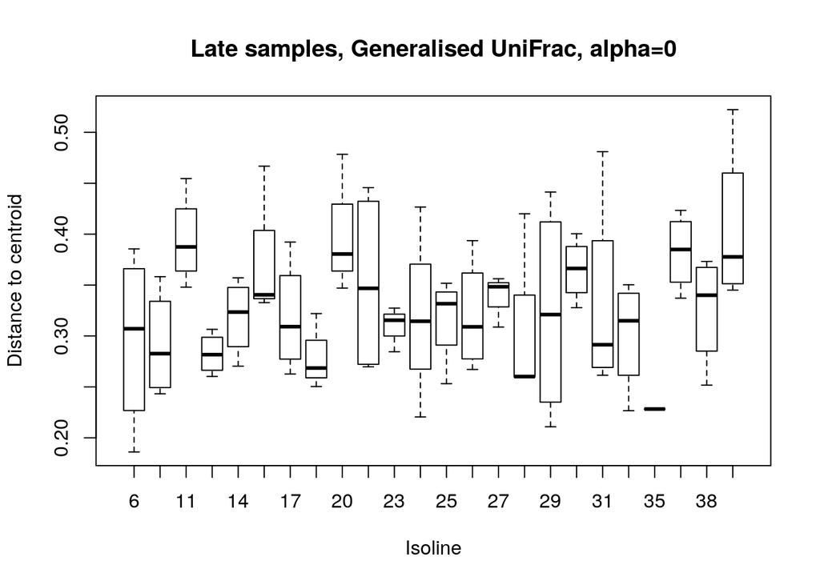

```r
boxplot(betadisper(LateDist, SampleData[isLate & Sample.filter, 'isoline']),
        xlab='Isoline', main='Late samples, Generalised UniFrac, alpha=0')
```

The nice thing of the PCoA plots above is that I can see the variation in composition among biological replicates, and among isolines. About the boxplots, I remark first what we already know: early samples are further away from their isoline centroids than late samples. The different amounts of dispersion among isolines, both early and late in life are not significant, probably due to the limited number of replicates (3 or 4).

## Analysis of variance using distance matrices

Another thing we can do with $\beta$ diversity is to see how well its distribution corresponds to factors that characterize the samples, namely: age, isoline and sequencing batch. The difference with the tests of homogeneity performed above is that now I will be correlating the actual position (not just the dispersions) of samples in the multidimensional ASV space with their attributes. It is quite similar to a constrained ordination analysis, like redundancy analysis. But in contrast to my previous attempts to run redundancy analyses, here I focus in explaining microbiome compositions, rather than using them to explain physiological variation in the hosts.

```r
# No need to save the results
adonis2(UF0 ~ age * isoline + seqrun, data = SampleData[Sample.filter,], by='terms')
```

```
## Permutation test for adonis under reduced model
## Terms added sequentially (first to last)
## Permutation: free
## Number of permutations: 999
##
## adonis2(formula = UF0 ~ age * isoline + seqrun, data = SampleData[Sample.filter, ], by = "terms")
##              Df SumOfSqs      R2       F Pr(>F)
## age           1    4.048 0.09112 22.9289  0.001 ***
## isoline      23    9.888 0.22257  2.4351  0.001 ***
## seqrun        1    0.245 0.00553  1.3904  0.091 .
## age:isoline  23    8.000 0.18008  1.9703  0.001 ***
## Residual    126   22.244 0.50071
## Total       174   44.425 1.00000
## ---
## Signif. codes:  0 '***' 0.001 '**' 0.01 '*' 0.05 '.' 0.1 ' ' 1
```

```r
adonis2(UF5 ~ age * isoline + seqrun, data = SampleData[Sample.filter,], by='terms')
```

```
## Permutation test for adonis under reduced model
## Terms added sequentially (first to last)
## Permutation: free
## Number of permutations: 999
##
## adonis2(formula = UF5 ~ age * isoline + seqrun, data = SampleData[Sample.filter, ], by = "terms")
##              Df SumOfSqs      R2       F Pr(>F)
## age           1   0.6402 0.16139 68.3890  0.001 ***
## isoline      23   1.2441 0.31360  5.7779  0.001 ***
## seqrun        1   0.0140 0.00353  1.4964  0.170
## age:isoline  23   0.8892 0.22414  4.1297  0.001 ***
## Residual    126   1.1796 0.29734
## Total       174   3.9671 1.00000
## ---
## Signif. codes:  0 '***' 0.001 '**' 0.01 '*' 0.05 '.' 0.1 ' ' 1
```

```r
adonis2(Ar[Sample.filter, ASV.filter] ~ age * isoline + seqrun,
        data = SampleData[Sample.filter,], by='terms')
```

```
## Permutation test for adonis under reduced model
## Terms added sequentially (first to last)
## Permutation: free
## Number of permutations: 999
##
## adonis2(formula = Ar[Sample.filter, ASV.filter] ~ age * isoline + seqrun, data = SampleData[Sample.filter, ], by = "terms")
##              Df SumOfSqs      R2       F Pr(>F)
## age           1    3.947 0.10180 49.5356  0.001 ***
## isoline      23   13.845 0.35707  7.5545  0.001 ***
## seqrun        1    0.257 0.00663  3.2247  0.006 **
## age:isoline  23   10.685 0.27556  5.8300  0.001 ***
## Residual    126   10.040 0.25894
## Total       174   38.774 1.00000
## ---
## Signif. codes:  0 '***' 0.001 '**' 0.01 '*' 0.05 '.' 0.1 ' ' 1
```

## Cannonical correspondance analysis

Exploratory ordination plots are available in `2020-03-25`. What I haven’t done yet is a constrained (or canonical) correspondance analysis (CCA) using age, isoline and sequencing batch as constraining factors. It is probably unnecessary, after having shown that both isoline and age, and their interaction, significantly affect the ASV composition of microbiomes.

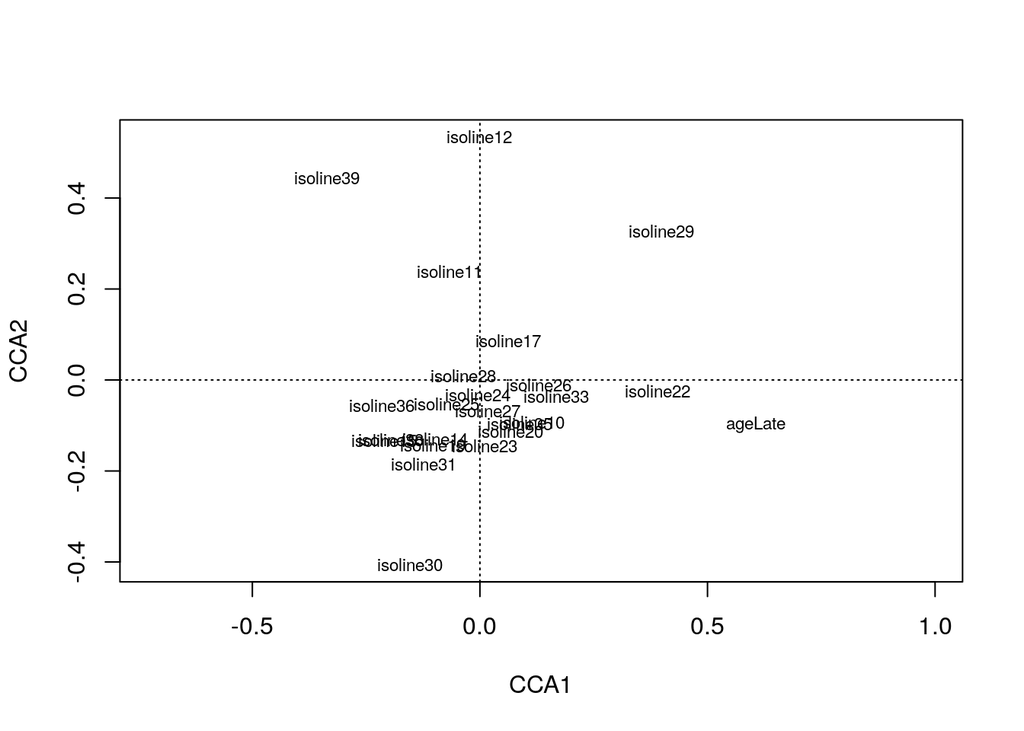

```r
Ar.cca <- cca(Ar[Sample.filter, ASV.filter] ~ isoline + age + Condition(seqrun),
              data = SampleData[Sample.filter,])
plot(Ar.cca, display='bp')
```

Using ASV, instead of phyla or genera, prevents any useful display of *species* in the biplot. Let’s see if using genera we get something more interesting.

```r
Genera.cca <- cca(Genera.counts[Sample.filter, Genus.filter] ~ isoline + age + Condition(seqrun),
                  data = SampleData[Sample.filter,])
Genera.cca
```

```
## Call: cca(formula = Genera.counts[Sample.filter, Genus.filter] ~
## isoline + age + Condition(seqrun), data = SampleData[Sample.filter, ])
##
##               Inertia Proportion Rank
## Total         0.80367    1.00000
## Conditional   0.02431    0.03025    1
## Constrained   0.19040    0.23692   24
## Unconstrained 0.58896    0.73284   68
## Inertia is scaled Chi-square
##
## Eigenvalues for constrained axes:
##    CCA1    CCA2    CCA3    CCA4    CCA5    CCA6    CCA7    CCA8    CCA9   CCA10
## 0.09342 0.06772 0.00788 0.00730 0.00561 0.00288 0.00237 0.00073 0.00062 0.00045
##   CCA11   CCA12   CCA13   CCA14   CCA15   CCA16   CCA17   CCA18   CCA19   CCA20
## 0.00030 0.00027 0.00026 0.00020 0.00015 0.00011 0.00006 0.00003 0.00003 0.00002
##   CCA21   CCA22   CCA23   CCA24
## 0.00001 0.00000 0.00000 0.00000
##
## Eigenvalues for unconstrained axes:
##     CA1     CA2     CA3     CA4     CA5     CA6     CA7     CA8
## 0.23542 0.09980 0.06994 0.05101 0.03314 0.01905 0.01593 0.00988
## (Showing 8 of 68 unconstrained eigenvalues)
```

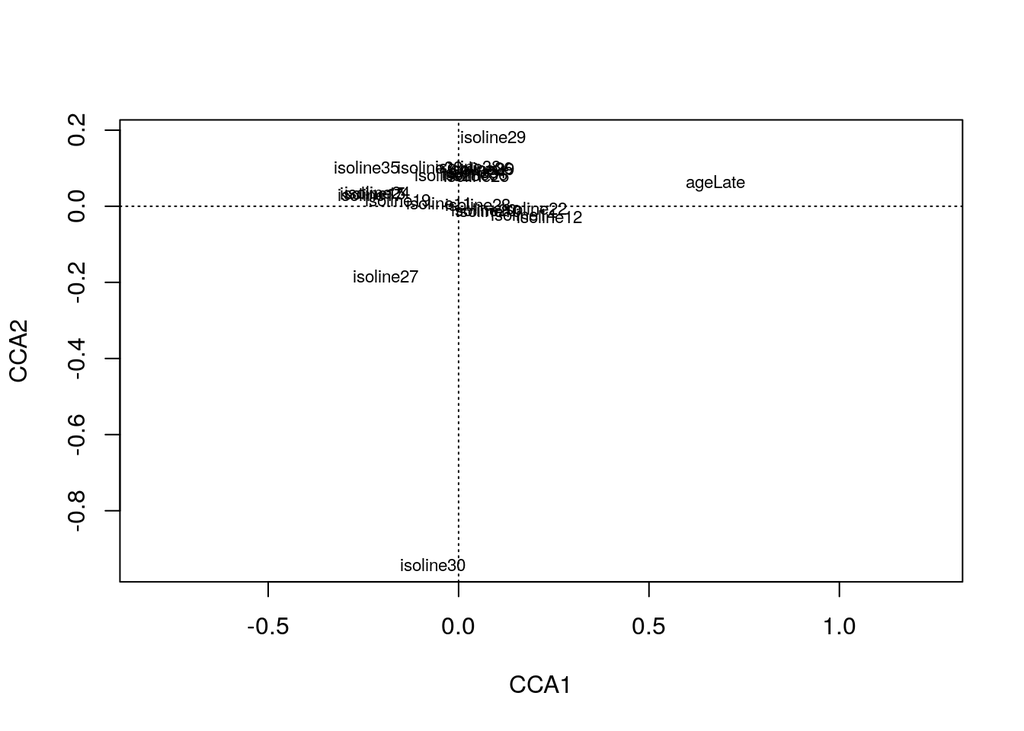

```r
plot(Genera.cca, display='bp')
```

# Life history variables of isolines.

Life history variables include two missing data. I use 10 different imputations to get a sense of the uncertainty due to missing data. Note I impute values using all information available, and only then I select the isolines for which we have microbiome data and the variables of interest.

```r
LH$LateRS <- LH$EarlyRS - LH$Rsen
#LH <- LH[,-which(names(LH) %in% 'Rsen')]
LHc <- apply(LH, 2, function(x) (x - mean(x, na.rm=TRUE)) / sd(x, na.rm=TRUE))
set.seed(1007)
LHc.imp <- mice(LHc, m=10)
```

```
##
##  * Please inspect the loggedEvents
```

```r
LH.all <- complete(LHc.imp, action='all')
validIsolines  <- row.names(EA)
validVariables <- c('CSearly', 'CSlate', 'EarlyRS', 'Rsen', 'AvLF', 'ActuarialB')
LH.all <- lapply(LH.all, function(x, f1=validIsolines, f2=validVariables) x[f1, f2])
```

Using life-history variables forces me to adopt an isoline-centered perspective. I need to use now the `EA` and `LA` matrices where abundance data from replicates is collapsed at the isoline level.

A first question is if diversity measures by themselves could explain any of the variation in life history variables. I will use `DiverIso.wide` data frame, created on `2020-04-22`, which includes measures of phylogenetic diversity for early and late samples in every isoline. I add genus diversity.

```r
Genera.early <- do.call(rbind, lapply(split(as.data.frame(Genera.counts[isEarly,]),
                                            SampleData[isEarly, 'isoline']), colSums))
Genera.late  <- do.call(rbind, lapply(split(as.data.frame(Genera.counts[isLate, ]),
                                            SampleData[isLate,  'isoline']), colSums))
DiverIso.wide$Shannon.Genus.E <- diversity(Genera.early, index='shannon')
DiverIso.wide$Shannon.Genus.L <- diversity(Genera.late, index='shannon')
DiverIso.wide$Simpson.Genus.E <- diversity(Genera.early, index='simpson')
DiverIso.wide$Simpson.Genus.L <- diversity(Genera.late, index='simpson')

sapply(DiverIso.wide, skewness)
```

```
##         isoline        PD.Early        SR.Early       Shannon.E       Simpson.E
##              NA    -0.567967956    -0.372791095    -0.153691056    -0.334160704
##        SeqNum.E         PD.Late         SR.Late       Shannon.L       Simpson.L
##     0.141973671    -0.001151481    -0.274002515    -0.360039982    -1.066248806
##        SeqNum.L           batch Shannon.Genus.E Shannon.Genus.L Simpson.Genus.E
##     3.689843489    -0.043896576     0.823170801     1.205034526     0.626550279
## Simpson.Genus.L
##     1.278531675
```

```r
Predictors <- DiverIso.wide[, c('PD.Early','PD.Late','SR.Early','SR.Late',
                                'Shannon.E','Shannon.L','Shannon.Genus.E',
                                'Shannon.Genus.L')]

# First, I fit a null model with only the intercept
RDA0 <- lapply(LH.all, function(lh) rda(lh ~ 1, data=Predictors))
# This is the complete model, with all diversity measures
RDAX <- lapply(LH.all, function(lh) rda(lh ~ ., data=Predictors))
RDAX.aov <- lapply(RDAX, anova)
sapply(RDAX.aov, function(x) x$'Pr(>F)'[1])
```

```
##     1     2     3     4     5     6     7     8     9    10
## 0.914 0.835 0.758 0.782 0.854 0.850 0.875 0.835 0.852 0.924
```

```r
# This is an automatic model selection procedure
RDA <- lapply(RDA0, function(x) ordiR2step(x, RDAX[[1]], trace=FALSE, Pin=0.1,
                                           Pout=0.15, R2scope=FALSE))
sapply(RDA, function(x) x$terms[[3]])
```

```
## $`1`
## [1] 1
##
## $`2`
## [1] 1
##
## $`3`
## SR.Early
##
## $`4`
## [1] 1
##
## $`5`
## [1] 1
##
## $`6`
## [1] 1
##
## $`7`
## [1] 1
##
## $`8`
## [1] 1
##
## $`9`
## [1] 1
##
## $`10`
## [1] 1
```

I don’t see any measure of diversity, neither by itself nor combined with others, significantly correlated with life history traits. I conclude that having a more or less diverse microbiome does not, by itself, affect fitness.

# The role of amplicons or taxa that changed abundance between early and late time points

On `2020-03-17` I fit the model `~ seqrun + isoline + age` to amplicon abundances using the `DESeq2` package. Amplicons with a significant difference in abundance between early and late samples reflect a common response from all or most isolines. When trying to explain the variance in life-history traits among isolines, the most interesting amplicons are actually those that vary among isolines.

Later on, I complemented the analysis in `2020-03-17`. I selected the subset of amplicons for which a likelihood ratio test showed that the *isoline* term produced a significantly better fit (`AmpliconsIsolineTerm`); and the subset of them with a significant interaction term between *isoline* and *age*.

I want to note that *DESeq2* does not allow for mixed models. Maybe I could try the package *VariancePartition*, with the `dream()` function.

Below, I finally got a (marginally) significant global fit. It worked using only the early abundances of the amplicons with the lowest pvalue of the LRT for the interaction term, after transforming the relative abundances to reduce the skew, and removing those that remained too skewed. An appropriate maximum skewness proved essential to obtain the almost significant results.

```r
SelectedAmplicons <- rownames(res2[res2$padj < 0.001, ])
#SelectedAmplicons  <- rownames(res2[order(res2$pvalue), ])[1:23]
z <- log10(EA.prop[, SelectedAmplicons] + 1.0e-07)
dim(z)
```

```
## [1] 24 71
```

```r
# I tried different skewness thresholds to get fewer than 24 ASVs.
z  <- z[, abs(apply(z, 2, skewness)) < 0.25]
dim(z)
```

```
## [1] 24 18
```

```r
if (dim(z)[2] > 23) {
  # Not used
  print('Using PCA')
  z.pca <- prcomp(z)
  Predictors <- as.data.frame(z.pca$x[, 1:22])
  print(sprintf("%% of variance: %.4f %%", 100 * sum(eigenvals(z.pca)[1:22])/sum(eigenvals(z.pca))))
} else {
  print(sprintf('Using %i amplicons', dim(z)[2]))
  Predictors <- as.data.frame(z[,1:(dim(z)[2])])
}
```

```
## [1] "Using 18 amplicons"
```

```r
RDA0 <- lapply(LH.all, function(lh) rda(lh ~ 1, data=Predictors))
RDAX <- lapply(LH.all, function(lh) rda(lh ~ ., data=Predictors))
RDAX.aov <- lapply(RDAX, anova)
sapply(RDAX.aov, function(x) x$'Pr(>F)'[1])
```

```
##     1     2     3     4     5     6     7     8     9    10
## 0.038 0.040 0.213 0.049 0.019 0.029 0.031 0.038 0.027 0.032
```

The 10 values above are the p-values for the global test in the 10 datasets produced by multiple imputation. They are the lowest p values I have seen in a global test till now. This is a good start to build a model. Even relaxing the thresholds, a forward selection model departing from the null model with only the intercept only adds one ASV (A0071, *Acetobacter*, of course). Below I use a backward selection procedure to remove from the complete model the irrelevant terms.

```r
RDA <- lapply(RDAX, function(x) ordistep(x, RDAX[[1]], trace=FALSE, Pin=0.05,
                                         direction = 'backward', Pout=0.1, steps=500))
```

```r
#RDA <- lapply(RDA0, function(x) ordiR2step(x, RDAX[[1]], trace=FALSE,
#                                           Pin=0.15, Pout=0.2, R2scope=FALSE))
# Number of models a terms appears in:
TermUsage <- table(unlist(sapply(RDA, function(x) attr(x$terminfo$terms, 'term.labels'))))
TermUsage
```

```
##
## A0059 A0064 A0065 A0071 A0085 A0097 A0113 A0123
##     7     5    10    10     7     8     5    10
```

```r
UsedTerms <- names(TermUsage[TermUsage >= 7])
RDA <- lapply(LH.all, function(lh) rda(lh ~ ., data=Predictors[,UsedTerms]))
sapply(RDA, function(x) summary(x)$constr.chi / summary(x)$tot.chi)
```

```
##         1         2         3         4         5         6         7         8
## 0.4976038 0.5115840 0.4859511 0.5049058 0.5148754 0.5165113 0.5148412 0.5132691
##         9        10
## 0.5143522 0.4976361
```

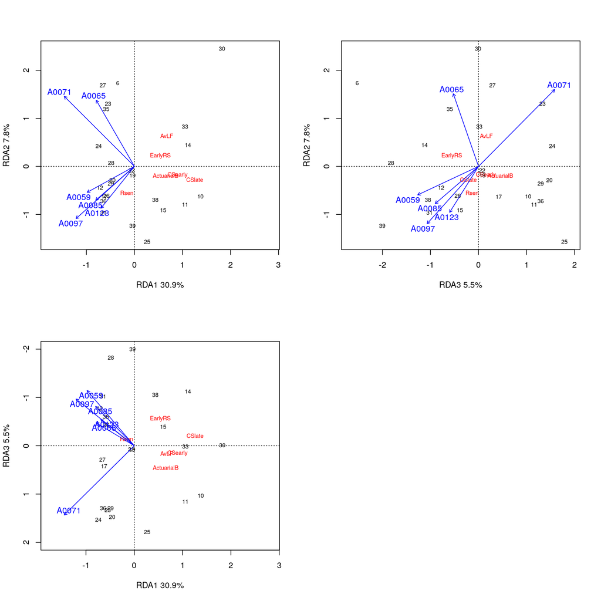

```r
par(mfrow=c(2,2))
plot(RDA[[1]], choice=c(1,2), type='text', scaling=2,
     xlab=sprintf("RDA1 %.1f%%", 100 * summary(eigenvals(RDA[[1]]))[2,1]),
     ylab=sprintf("RDA2 %.1f%%", 100 * summary(eigenvals(RDA[[1]]))[2,2]))
plot(RDA[[1]], choice=c(3,2), type='text', scaling=2,
     xlab=sprintf("RDA3 %.1f%%", 100 * summary(eigenvals(RDA[[1]]))[2,3]),
     ylab=sprintf("RDA2 %.1f%%", 100 * summary(eigenvals(RDA[[1]]))[2,2]))
plot(RDA[[1]], choice=c(1,3), type='text', ylim=c(2, -2), scaling=2,
     xlab=sprintf("RDA1 %.1f%%", 100 * summary(eigenvals(RDA[[1]]))[2,1]),
     ylab=sprintf("RDA3 %.1f%%", 100 * summary(eigenvals(RDA[[1]]))[2,3]))
par(mfrow=c(1,1))
```

```r
png(filename='RDA.png', width = 480*2, height = 480*2)
par(mfrow=c(2,2), cex=1.3)
plot(RDA[[1]], choice=c(1,2), type='text', scaling=2,
     xlab=sprintf("RDA1 (%.1f%%)", 100 * summary(eigenvals(RDA[[1]]))[2,1]),
     ylab=sprintf("RDA2 (%.1f%%)", 100 * summary(eigenvals(RDA[[1]]))[2,2]))
plot(RDA[[1]], choice=c(3,2), type='text', scaling=2,
     xlab=sprintf("RDA3 (%.1f%%)", 100 * summary(eigenvals(RDA[[1]]))[2,3]),
     ylab=sprintf("RDA2 (%.1f%%)", 100 * summary(eigenvals(RDA[[1]]))[2,2]))
plot(RDA[[1]], choice=c(1,3), type='text', ylim=c(2, -2), scaling=2,
     xlab=sprintf("RDA1 (%.1f%%)", 100 * summary(eigenvals(RDA[[1]]))[2,1]),
     ylab=sprintf("RDA3 (%.1f%%)", 100 * summary(eigenvals(RDA[[1]]))[2,3]))
dev.off()
```

There are two groups of ASVs with different, apparently negative effects on fitness. First, A0065 and A0071 seem to *push* in a direction away from *CSlate* (late climbing speed). I name this group “functional agers”. Then, A0059, A0097 and A0123 move away from *AvLF* (average life span, I think); I name this group “life shorteners”. Are those ASVs scattered in the *Acetobacter* phylogeny? Or are they clusters of related clones?

```r
TreeTraits <- Traits[names(fitGTR$data),]
TreeTraits$label <- rownames(TreeTraits)
TreeAceto <- drop.tip(fitGTR$tree, TreeTraits[! TreeTraits$Genus %in% 'Acetobacter', 'label'])
TibbAceto <- as_tibble(TreeAceto)
TibbAceto$modelTerms <- TibbAceto$label %in% UsedTerms
TDAceto <- as.treedata(TibbAceto)
TDAceto <- treeio::drop.tip(TDAceto, c('A1543', 'A1910', 'A2130', 'A2172',
                                      'A1818', 'A1067', 'A1306', 'A1787', 'A1962'))
```

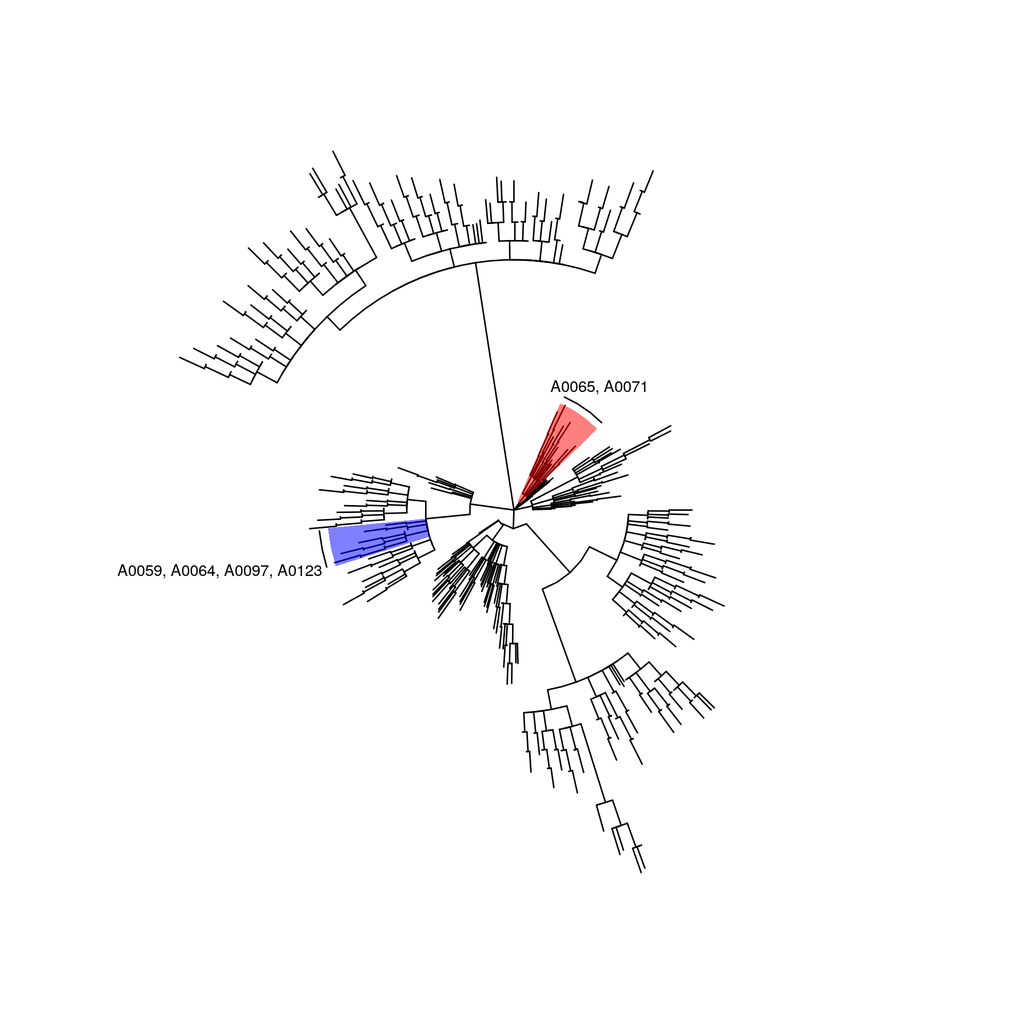

```r
ggtree(TDAceto, layout='circular') +
  geom_hilight(node=MRCA(TDAceto, c('A0059','A0064','A0097','A0123')), fill='blue', alpha=0.5) +
  geom_hilight(node=MRCA(TDAceto, c('A0065','A0071')), fill='red', alpha=0.5) +
  geom_cladelabel(node=MRCA(TDAceto, c('A0059','A0064','A0097','A0123')),
                  label='A0059, A0064, A0097, A0123',
                  offset=0.01, offset.text=0.2, hjust='center') +
  geom_cladelabel(node=MRCA(TDAceto, c('A0065','A0071')), label='A0065, A0071',
                  offset=0.01, offset.text=0.05, hjust='center')
```

```r
ggsave('RDAtree.png')
```

They are clearly clustered, which suggests that several other ASV with related sequences should also have similar effects.

```r
nodes.FA <- offspring(TDAceto, MRCA(TDAceto, c('A0065','A0071')), tiponly=TRUE)
nodes.LS <- offspring(TDAceto, MRCA(TDAceto, c('A0059','A0064','A0097','A0123')), tiponly=TRUE)
FunctionalAgers <- TibbAceto[TibbAceto$node %in% nodes.FA, 'label']$label
LifeShorteners  <- TibbAceto[TibbAceto$node %in% nodes.LS, 'label']$label

Predictors <- data.frame(
  FA = log10(apply(EA.prop[,FunctionalAgers], 1, mean) + 1.0e-7),
  LS = log10(apply(EA.prop[,LifeShorteners], 1, mean) + 1.0e-7)
)

RDA2 <- lapply(LH.all, function(lh) rda(lh ~ FA, data=Predictors))
RDA2.aov <- lapply(RDA2, anova)
sapply(RDA2.aov, function(x) x$'Pr(>F)'[1])
```

```
##     1     2     3     4     5     6     7     8     9    10
## 0.314 0.274 0.217 0.248 0.317 0.322 0.306 0.304 0.313 0.252
```

```r
rm(RDA2.aov)
```

Either the combined or the average early abundances of presumed *functional agers* or *life shorteners* added more noise than signal. The relatinship with life history traits disappears when using all ASV in their clusters. This does not invalidate the results, but adds a note of caution.

# References

Anderson, Marti J. n.d. “Distance-Based Tests for Homogeneity of Multivariate Dispersions.” *Biometrics* 62: 245–53. https://doi.org/10.1111/j.1541-0420.2005.00440.x.

Chen, Jun, Kyle Bittinger, Emily S. Charlson, Christian Hoffmann, James Lewis, Gary D. Wu, Ronald G. Collman, Frederic D. Bushman, and Hongzhe Li. 2012. “Associating Microbiome Composition with Environmental Covariates Using Generalized Unifrac Distances.” *Bioinformatics* 28 (16): 2106–13. https://doi.org/10.1093/bioinformatics/bts342.

Oksanen, Jari, F. Guillaume Blanchet, Michael Friendly, Roeland Kindt, Pierre Legendre, Dan McGlinn, Peter R. Minchin, et al. 2019. *Vegan: Community Ecology Package*. https://CRAN.R-project.org/package=vegan.